# 2019 Ford Go-Bike Project(Part 1/2)

Introduction

Preliminary Wrangling

Data Cleaning

Exploration Data Analysis (EDA)

Univariate

Bivariate

Multivariate

Conclusions

### 1. Introduction

As the capstone project for the Udacity Data Analysis Nanodegree course, this project's two halves show the significance and utility of data visualization approaches in the data analysis process.

The 2019-fordgobike-tripdata datafile will be carefully wrangled and explored in this part (1/2), starting with plots of single variables and progressing to plots of multiple variables.

I will create a brief presentation that highlights the intriguing characteristics, patterns, and connections I found in the chosen (cleaned) dataset for the next second half of the project (2/2). (Based on another file 2019-fordgobike-tripdata clean, a project part 1 output.

### 1.1. Dataset and its origin

Bay Wheels is a regional public bicycle sharing program run by Motivate in collaboration with the Metropolitan Transportation Commission and the Bay Area Air Quality Management District in the San Francisco Bay Area, California. [3] The first regional and extensive bicycle sharing program to be implemented on the West Coast of the United States is called Bay Wheels. In August 2013, it became known as Bay Area Bike Share. Over 2,600 bicycles were available through the Bay Wheels system at 262 stations in San Francisco, the East Bay, and San Jose as of January 2018. In a collaboration with Ford Motor Company, the system was formally re-launched as Ford GoBike on June 28, 2017. The system was later renamed to Bay Wheels in June following Motivate's acquisition by Lyft.

The 2019 Ford Go-Bike DataSet contains details about each ride taken in the system's service area, which includes the larger San Francisco Bay area. The whole dataset includes information on a large number of cities, and data are also accessible for prior years; however, I will concentrate my study on 2019 and the San Francisco Bay area.

## Data

- Trip Duration (seconds)
- Start Time and Date
- End Time and Date
- Start Station ID
- Start Station Name
- Start Station Latitude
- Start Station Longitude
- End Station ID
- End Station Name
- End Station Latitude
- End Station Longitude
- Bike ID
- User Type (Subscriber or Customer – “Subscriber” = Member or “Customer” = Casual)
- bike share for all trip
- rental access method

```python
# importing the required libararies
import pandas as pd
import numpy as np
import matplotlib.pyplot as plt
import seaborn as sb
import matplotlib.patches as mpatches
import calendar
import math
import time
%matplotlib inline
```

```python
import warnings
warnings.filterwarnings('ignore')
```

```python
# Reading the dataset
df = pd.read_csv('201902-fordgobike-tripdata.csv')
df.head()
```

|  | duration_sec | start_time | end_time | start_station_id | start_station_name | start_station_latitude | start_station_longitude | end_station_id | end_station_name | end_station_latitude | end_station_longitude | bike_id | user_type | member_birth_year | member_gender | bike_share_for_all_trip |
| --- | --- | --- | --- | --- | --- | --- | --- | --- | --- | --- | --- | --- | --- | --- | --- | --- |
| 0 | 52185 | 2019-02-28 17:32:10.1450 | 2019-03-01 08:01:55.9750 | 21.0 | Montgomery St BART Station (Market St at 2nd St) | 37.789625 | -122.400811 | 13.0 | Commercial St at Montgomery St | 37.794231 | -122.402923 | 4902 | Customer | 1984.0 | Male | No |
| 1 | 42521 | 2019-02-28 18:53:21.7890 | 2019-03-01 06:42:03.0560 | 23.0 | The Embarcadero at Steuart St | 37.791464 | -122.391034 | 81.0 | Berry St at 4th St | 37.775880 | -122.393170 | 2535 | Customer | NaN | NaN | No |
| 2 | 61854 | 2019-02-28 12:13:13.2180 | 2019-03-01 05:24:08.1460 | 86.0 | Market St at Dolores St | 37.769305 | -122.426826 | 3.0 | Powell St BART Station (Market St at 4th St) | 37.786375 | -122.404904 | 5905 | Customer | 1972.0 | Male | No |
| 3 | 36490 | 2019-02-28 17:54:26.0100 | 2019-03-01 04:02:36.8420 | 375.0 | Grove St at Masonic Ave | 37.774836 | -122.446546 | 70.0 | Central Ave at Fell St | 37.773311 | -122.444293 | 6638 | Subscriber | 1989.0 | Other | No |
| 4 | 1585 | 2019-02-28 23:54:18.5490 | 2019-03-01 00:20:44.0740 | 7.0 | Frank H Ogawa Plaza | 37.804562 | -122.271738 | 222.0 | 10th Ave at E 15th St | 37.792714 | -122.248780 | 4898 | Subscriber | 1974.0 | Male | Yes |

```python
df.info()
```

```
<class 'pandas.core.frame.DataFrame'>
RangeIndex: 183412 entries, 0 to 183411
Data columns (total 16 columns):
 #   Column                   Non-Null Count   Dtype
---  ------                   --------------   -----
 0   duration_sec             183412 non-null  int64
 1   start_time               183412 non-null  object
 2   end_time                 183412 non-null  object
 3   start_station_id         183215 non-null  float64
 4   start_station_name       183215 non-null  object
 5   start_station_latitude   183412 non-null  float64
 6   start_station_longitude  183412 non-null  float64
 7   end_station_id           183215 non-null  float64
 8   end_station_name         183215 non-null  object
 9   end_station_latitude     183412 non-null  float64
 10  end_station_longitude    183412 non-null  float64
 11  bike_id                  183412 non-null  int64
 12  user_type                183412 non-null  object
 13  member_birth_year        175147 non-null  float64
 14  member_gender            175147 non-null  object
 15  bike_share_for_all_trip  183412 non-null  object
dtypes: float64(7), int64(2), object(7)
memory usage: 22.4+ MB
```

```python
df.describe()
```

|  | duration_sec | start_station_id | start_station_latitude | start_station_longitude | end_station_id | end_station_latitude | end_station_longitude | bike_id | member_birth_year |
| --- | --- | --- | --- | --- | --- | --- | --- | --- | --- |
| count | 183412.000000 | 183215.000000 | 183412.000000 | 183412.000000 | 183215.000000 | 183412.000000 | 183412.000000 | 183412.000000 | 175147.000000 |
| mean | 726.078435 | 138.590427 | 37.771223 | -122.352664 | 136.249123 | 37.771427 | -122.352250 | 4472.906375 | 1984.806437 |
| std | 1794.389780 | 111.778864 | 0.099581 | 0.117097 | 111.515131 | 0.099490 | 0.116673 | 1664.383394 | 10.116689 |
| min | 61.000000 | 3.000000 | 37.317298 | -122.453704 | 3.000000 | 37.317298 | -122.453704 | 11.000000 | 1878.000000 |
| 25% | 325.000000 | 47.000000 | 37.770083 | -122.412408 | 44.000000 | 37.770407 | -122.411726 | 3777.000000 | 1980.000000 |
| 50% | 514.000000 | 104.000000 | 37.780760 | -122.398285 | 100.000000 | 37.781010 | -122.398279 | 4958.000000 | 1987.000000 |
| 75% | 796.000000 | 239.000000 | 37.797280 | -122.286533 | 235.000000 | 37.797320 | -122.288045 | 5502.000000 | 1992.000000 |
| max | 85444.000000 | 398.000000 | 37.880222 | -121.874119 | 398.000000 | 37.880222 | -121.874119 | 6645.000000 | 2001.000000 |

```python
df.shape
```

```
(183412, 16)
```

```python
df['user_type'].value_counts()
```

```
Subscriber    163544
Customer       19868
Name: user_type, dtype: int64
```

## What is the structure of your dataset?

- The dataset contains the details of 183412 trios with 16 attributes
- Most variables are numeric in nature, but the variables start_station_name, end_station_name, user_type and member_gender are qualitative nominal variables

## What is/are the main feature(s) of interest in your dataset?

> I am most interested in figuring out when and where are most trips taken because this dataset includes start time/location and end time/location. I focus on the starting points first.

> The main features of interest at least for me are: age, user type,time, gender, start and end station

## What features in the dataset do you think will help support your investigation into your feature(s) of interest?

> User_type either customer or subscriber should have affect the most trips taken.

> Gender and Age of the users should also have affect the most trips taken.

> When are most trips taken in terms of time of day, day of the week, or month of the year?

# Data cleaning

```python
# checking for the null values
df.isnull().sum()
```

```
duration_sec                  0
start_time                    0
end_time                      0
start_station_id            197
start_station_name          197
start_station_latitude        0
start_station_longitude       0
end_station_id              197
end_station_name            197
end_station_latitude          0
end_station_longitude         0
bike_id                       0
user_type                     0
member_birth_year          8265
member_gender              8265
bike_share_for_all_trip       0
dtype: int64
```

```python
df.dropna(axis = 0 , inplace = True)
```

```python
# checking the null values after the dropping.
df.isnull().sum()
```

```
duration_sec               0
start_time                 0
end_time                   0
start_station_id           0
start_station_name         0
start_station_latitude     0
start_station_longitude    0
end_station_id             0
end_station_name           0
end_station_latitude       0
end_station_longitude      0
bike_id                    0
user_type                  0
member_birth_year          0
member_gender              0
bike_share_for_all_trip    0
dtype: int64
```

```python
# checking the new shape of the dataframe.
df.shape
```

```
(174952, 16)
```

```python
# Checking the unique values
df.nunique()
```

```
duration_sec                 4429
start_time                 174941
end_time                   174939
start_station_id              329
start_station_name            329
start_station_latitude        329
start_station_longitude       329
end_station_id                329
end_station_name              329
end_station_latitude          329
end_station_longitude         329
bike_id                      4607
user_type                       2
member_birth_year              75
member_gender                   3
bike_share_for_all_trip         2
dtype: int64
```

```python
# checking if there is any duplicates on the dataframe
df.duplicated().sum()
```

```
0
```

```python
# checking the data type of each column of the dataset
df.dtypes
```

```
duration_sec                 int64
start_time                  object
end_time                    object
start_station_id           float64
start_station_name          object
start_station_latitude     float64
start_station_longitude    float64
end_station_id             float64
end_station_name            object
end_station_latitude       float64
end_station_longitude      float64
bike_id                      int64
user_type                   object
member_birth_year          float64
member_gender               object
bike_share_for_all_trip     object
dtype: object
```

```python
# converting the start_time and end_time to datetime type format
df.start_time = pd.to_datetime(df.start_time)
df.end_time = pd.to_datetime(df.end_time)
df['start_month_num'] = df['start_time'].apply(lambda time: time.month)
df['start_month_char'] = df['start_month_num'].apply(lambda x: calendar.month_abbr[x])
```

```python
# Test: take a look at start_month_num and start_month_char
print(df['start_month_num'].value_counts())
print(df['start_month_char'].value_counts())
```

```
2    174952
Name: start_month_num, dtype: int64
Feb    174952
Name: start_month_char, dtype: int64
```

```python
# checking the unique values of the start_time_month
df['start_month_num'].unique()

# Seems that all the trips of study happened at one month which is February, so the month will not a factor of study.
```

```
array([2], dtype=int64)
```

```python
 # b. morning, afternoon, night of a day
df['start_hour'] = df['start_time'].apply(lambda time: time.hour)
df['period_day'] = 'morning'
df['period_day'][(df['start_hour'] >= 12) & (df['start_hour'] <= 17)] = 'afternoon'
df['period_day'][(df['start_hour'] >= 18) & (df['start_hour'] <= 23)] = 'night'
```

```python
# Test: start hour and time of day
print(df['start_hour'].value_counts())
print(df['period_day'].value_counts())
```

```
17    20904
8     20227
18    16118
9     15204
16    13473
7     10231
19     9424
15     8646
12     8220
13     8098
10     7970
14     7677
11     7461
20     6211
21     4400
6      3293
22     2793
23     1572
0       893
5       866
1       525
2       355
4       227
3       164
Name: start_hour, dtype: int64
morning      67416
afternoon    67018
night        40518
Name: period_day, dtype: int64
```

```python
# c. Day of the week
df['start_weekday_num'] = df['start_time'].apply(lambda time: time.dayofweek)
dmap = {0:'Mon',1:'Tue',2:'Wed',3:'Thu',4:'Fri',5:'Sat',6:'Sun'}
df['start_weekday_char'] = df['start_weekday_num'].map(dmap)
```

```python
# Test: take a look at start_weekday_num and start_weekday_char
print(df['start_weekday_num'].value_counts())
print(df['start_weekday_char'].value_counts())
```

```
3    33712
1    30584
2    28426
4    27663
0    25641
6    14512
5    14414
Name: start_weekday_num, dtype: int64
Thu    33712
Tue    30584
Wed    28426
Fri    27663
Mon    25641
Sun    14512
Sat    14414
Name: start_weekday_char, dtype: int64
```

```python
# convert time period, month, and weekday into ordered categorical types
ordinal_var_dict = {'period_day': ['morning', 'afternoon', 'night'],
                    'start_weekday_char': ['Mon', 'Tue', 'Wed', 'Thu', 'Fri', 'Sat', 'Sun']}

for var in ordinal_var_dict:
    ordered_var = pd.api.types.CategoricalDtype(ordered = True,
                                                categories = ordinal_var_dict[var])
    df[var] = df[var].astype(ordered_var)
```

```python
#convert datatype of bike_share_for_all_trip and user_type from string to category.
df['bike_share_for_all_trip']=df['bike_share_for_all_trip'].astype('category')
df['user_type'] = df['user_type'].astype('category')
```

```python
# start_station_id, end_station_id and bike_id should be object data type not numerical variables
df['start_station_id'] = df['start_station_id'].astype('object')
df['end_station_id'] = df['end_station_id'].astype('object')
df['bike_id'] = df['bike_id'].astype('object')
```

```python
# create new column with day name
df['day_of_week'] = df['start_time'].dt.day_name()
```

```python
# dictionary to pass to replace method to determine which day is weekday and which day is weekend
day_convert={'Saturday':'Weekend','Sunday':'Weekend','Monday':'Weekday','Tuesday':'Weekday','Wednesday':'Weekday','Friday':'Weekday','Thursday':'Weekday'}
#create column to indicate weekdays and weekends
df['state_of_day']=df['day_of_week'].replace(day_convert)
```

```python
# 2. Create ages
df['member_age'] = 2019 - df['member_birth_year']
```

```python
# Changing the datatype of both member_birth_year and member_age to int datatype.
df['member_age'] = df['member_age'].astype(int)
df['member_birth_year'] = df['member_birth_year'].astype(int)
```

```python
#checking dtypes
df.dtypes
```

```
duration_sec                        int64
start_time                 datetime64[ns]
end_time                   datetime64[ns]
start_station_id                   object
start_station_name                 object
start_station_latitude            float64
start_station_longitude           float64
end_station_id                     object
end_station_name                   object
end_station_latitude              float64
end_station_longitude             float64
bike_id                            object
user_type                        category
member_birth_year                   int32
member_gender                      object
bike_share_for_all_trip          category
start_month_num                     int64
start_month_char                   object
start_hour                          int64
period_day                       category
start_weekday_num                   int64
start_weekday_char               category
day_of_week                        object
state_of_day                       object
member_age                          int32
dtype: object
```

```python
# Checking All the changes
df.info()
```

```
<class 'pandas.core.frame.DataFrame'>
Int64Index: 174952 entries, 0 to 183411
Data columns (total 25 columns):
 #   Column                   Non-Null Count   Dtype
---  ------                   --------------   -----
 0   duration_sec             174952 non-null  int64
 1   start_time               174952 non-null  datetime64[ns]
 2   end_time                 174952 non-null  datetime64[ns]
 3   start_station_id         174952 non-null  object
 4   start_station_name       174952 non-null  object
 5   start_station_latitude   174952 non-null  float64
 6   start_station_longitude  174952 non-null  float64
 7   end_station_id           174952 non-null  object
 8   end_station_name         174952 non-null  object
 9   end_station_latitude     174952 non-null  float64
```

[output cut: 17 more lines]

```python
df.head(5)
```

|  | duration_sec | start_time | end_time | start_station_id | start_station_name | start_station_latitude | start_station_longitude | end_station_id | end_station_name | end_station_latitude | ... | bike_share_for_all_trip | start_month_num | start_month_char | start_hour | period_day | start_weekday_num | start_weekday_char | day_of_week | state_of_day | member_age |
| --- | --- | --- | --- | --- | --- | --- | --- | --- | --- | --- | --- | --- | --- | --- | --- | --- | --- | --- | --- | --- | --- |
| 0 | 52185 | 2019-02-28 17:32:10.145 | 2019-03-01 08:01:55.975 | 21.0 | Montgomery St BART Station (Market St at 2nd St) | 37.789625 | -122.400811 | 13.0 | Commercial St at Montgomery St | 37.794231 | ... | No | 2 | Feb | 17 | afternoon | 3 | Thu | Thursday | Weekday | 35 |
| 2 | 61854 | 2019-02-28 12:13:13.218 | 2019-03-01 05:24:08.146 | 86.0 | Market St at Dolores St | 37.769305 | -122.426826 | 3.0 | Powell St BART Station (Market St at 4th St) | 37.786375 | ... | No | 2 | Feb | 12 | afternoon | 3 | Thu | Thursday | Weekday | 47 |
| 3 | 36490 | 2019-02-28 17:54:26.010 | 2019-03-01 04:02:36.842 | 375.0 | Grove St at Masonic Ave | 37.774836 | -122.446546 | 70.0 | Central Ave at Fell St | 37.773311 | ... | No | 2 | Feb | 17 | afternoon | 3 | Thu | Thursday | Weekday | 30 |
| 4 | 1585 | 2019-02-28 23:54:18.549 | 2019-03-01 00:20:44.074 | 7.0 | Frank H Ogawa Plaza | 37.804562 | -122.271738 | 222.0 | 10th Ave at E 15th St | 37.792714 | ... | Yes | 2 | Feb | 23 | night | 3 | Thu | Thursday | Weekday | 45 |
| 5 | 1793 | 2019-02-28 23:49:58.632 | 2019-03-01 00:19:51.760 | 93.0 | 4th St at Mission Bay Blvd S | 37.770407 | -122.391198 | 323.0 | Broadway at Kearny | 37.798014 | ... | No | 2 | Feb | 23 | night | 3 | Thu | Thursday | Weekday | 60 |

5 rows × 25 columns

# Univariate Exploration

### Day with most trips

```python
weekend_color=sb.color_palette()[1]
weekday_color=sb.color_palette()[0]
color=[weekday_color,weekday_color,weekday_color,weekday_color,
       weekday_color,weekend_color,weekend_color]
order=['Monday','Tuesday','Wednesday','Thursday','Friday','Saturday','Sunday']
```

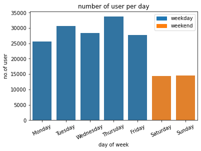

```python
sb.countplot(data=df,x='day_of_week',palette=color,order=order)
plt.xticks(rotation=25)
plt.title('number of user per day')
plt.ylabel('no.of user')
plt.xlabel('day of week')

# create alegend
red_patch = mpatches.Patch(color=weekday_color, label='weekday')
pathch=mpatches.Patch(color=weekend_color,label='weekend')
plt.legend(handles=[red_patch,pathch])
plt.show()
```

Users, whether they are customers or subscribers, commonly use the Bay Wheels service during the week, with the exception of Saturday and Sunday, which are weekends, so we can say that they use it for work, such as getting to and from work or school.

### Start Time Hour

```python
base_color = sb.color_palette()[0]
```

```python
hour_order = df['start_hour'].value_counts().index
```

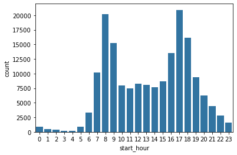

```python
sb.countplot(data = df , x= 'start_hour', color = base_color);
```

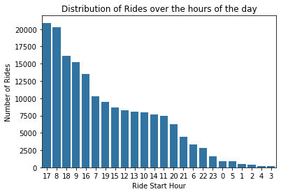

```python
# We can see the order here
sb.countplot(data = df , x= 'start_hour', color = base_color, order = hour_order);
plt.title('Distribution of Rides over the hours of the day')
plt.xlabel('Ride Start Hour')
plt.ylabel('Number of Rides')
plt.show()
```

#### Peak hours for riding is 5 P.M and 8 A.M (Those two hours are matching closely with the normal working hours for riders)

### Now Let's pay more attention to the bikers themselves, their gender, their age and also the user_type

### 1-Bikers' Gender

```python
df['member_gender'].value_counts()
```

```
Male      130500
Female     40805
Other       3647
Name: member_gender, dtype: int64
```

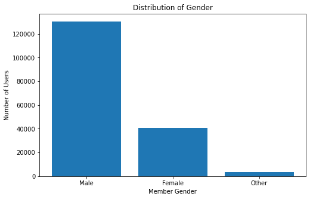

```python
# plotting genders
plt.figure(figsize=[8,5])
plt.bar(x = df.member_gender.value_counts().keys(), height = df.member_gender.value_counts() )
plt.title('Distribution of Gender')
plt.xlabel('Member Gender')
plt.ylabel('Number of Users')
plt.show()
```

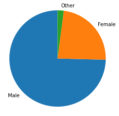

```python
# We can see the gender also on the pie chart
sorted_counts = df['member_gender'].value_counts()

plt.pie(sorted_counts, labels = sorted_counts.index, startangle = 90, counterclock = True);

plt.axis('square');
```

### We can conclude that Male Bikers are almost 3 times the female bikers.

### 2- Bikers' Age

```python
df['member_age'].value_counts()
```

```
31     10214
26      9323
30      8967
29      8640
28      8484
       ...
91         1
141        1
89         1
109        1
92         1
Name: member_age, Length: 75, dtype: int64
```

```python
df['member_age'].describe()

# Age 141 is an certainly outlier
```

```
count    174952.000000
mean         34.196865
std          10.118731
min          18.000000
25%          27.000000
50%          32.000000
75%          39.000000
max         141.000000
Name: member_age, dtype: float64
```

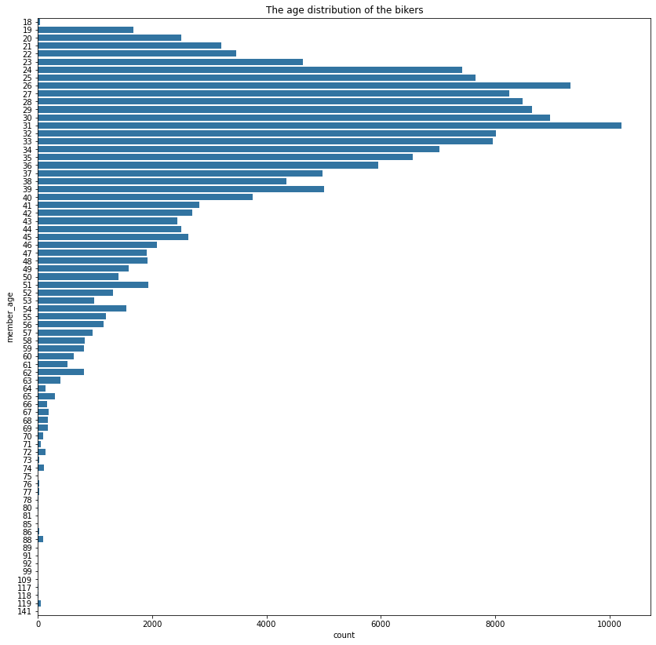

[output not shown]

```python
# By plotting Bar chart , we can identify the disturbution of bikers ages.
base_color = sb.color_palette()[0]
plt.figure(figsize=[14, 14])

ax = sb.countplot(data = df, y = 'member_age', color = base_color)
# Set title
ax.set_title("The age distribution of the bikers")
plt.show()
```

### Using this distribution, we can conclude that the major age range of bikers are 25-35.

### 3. Bikers Type

```python
df['user_type'].value_counts()
```

```
Subscriber    158386
Customer       16566
Name: user_type, dtype: int64
```

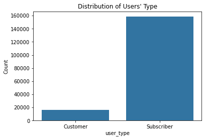

```python
sb.countplot(data = df, x = 'user_type', color = base_color);
plt.title("Distribution of Users' Type")
plt.xlabel('user_type')
plt.ylabel('Count')
plt.show()
```

[figure not shown]

```python
# By plotting Bar chart , we can identify the disturbution of Q1.
labels = list(df.user_type.unique())
sizes = df.user_type.value_counts()
explode = (0.16, 0)

fig1, ax1 = plt.subplots()
ax1.pie(sizes, labels=labels, autopct='%1.1f%%',
        shadow=True, startangle=90 , explode = explode )

ax1.axis('equal')
plt.tight_layout()
plt.title('User type distribution')
plt.show()
```

#### It's very clear that the subscriber users are around 9-10 times the customer users, this indicates long relationship and satisfactions from the users with the services provided to them.

### Start_Locations

```python
# Location: there are 329 start stations.
print(len(df['start_station_name'].value_counts()))
df['start_station_name'].value_counts()
```

```
329
```

```
Market St at 10th St                                         3649
San Francisco Caltrain Station 2  (Townsend St at 4th St)    3408
Berry St at 4th St                                           2952
Montgomery St BART Station (Market St at 2nd St)             2711
Powell St BART Station (Market St at 4th St)                 2620
                                                             ...
Farnam St at Fruitvale Ave                                      9
Parker Ave at McAllister St                                     7
21st Ave at International Blvd                                  4
Palm St at Willow St                                            3
16th St Depot                                                   2
Name: start_station_name, Length: 329, dtype: int64
```

```python
# Subset the dataset by keeping only top 8 locations with high traffics, df_top8.
locs = ['San Francisco Ferry Building (Harry Bridges Plaza)','The Embarcadero at Sansome St','San Francisco Caltrain (Townsend St at 4th St)','San Francisco Caltrain Station 2  (Townsend St at 4th St)','Market St at 10th St','Montgomery St BART Station (Market St at 2nd St)','Berry St at 4th St','Powell St BART Station (Market St at 4th St)']
df_top8 = df.loc[df['start_station_name'].isin(locs)]
```

```python
# Test and see if only keep top 8 station
df_top8['start_station_name'].value_counts()
```

```
Market St at 10th St                                         3649
San Francisco Caltrain Station 2  (Townsend St at 4th St)    3408
Berry St at 4th St                                           2952
Montgomery St BART Station (Market St at 2nd St)             2711
Powell St BART Station (Market St at 4th St)                 2620
San Francisco Caltrain (Townsend St at 4th St)               2577
San Francisco Ferry Building (Harry Bridges Plaza)           2541
The Embarcadero at Sansome St                                1975
Name: start_station_name, dtype: int64
```

```python
# After subsetting top 8 station with the most trip, create a countplot to see the distribution and order from top 1 to top 8
st_stat_counts = df_top8['start_station_name'].value_counts()
st_stat_order = st_stat_counts.index
```

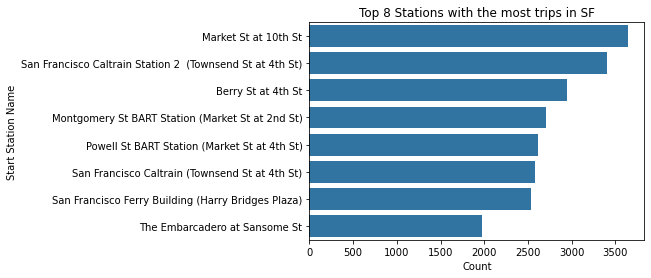

```python
base_color = sb.color_palette()[0]
sb.countplot(data=df_top8, y='start_station_name', color=base_color, order=st_stat_order)
plt.xlabel('Count')
plt.ylabel('Start Station Name')
plt.title('Top 8 Stations with the most trips in SF');
```

> After checking start and end stations, most stations in San Francisco connect to public transportations such as Caltrain, Bart and Ferry. The Embarcadero at Sansome St is very closed to Ferry building and located in financial distrit. Market St at 10th St and Berry St at 4th St are also closed to Bart station.

### Discuss the distribution(s) of your variable(s) of interest. Were there any unusual points? Did you need to perform any transformations?

> We have found that the work days were the most days that the users use the bike share system specially Thursday for this study.

> Also we have found that the peak hours for the users were 8 A.M and 5 P.M and those two hours are closely matching with the regular start and end working hours for most of the companies. Regarding the users, we have found that the males are almost 3 times the female users, the most age range is 25-35 and the subscriber users are almost 9-10 times the customer users.

### Of the features you investigated, were there any unusual distributions? Did you perform any operations on the data to tidy, adjust, or change the form of the data? If so, why did you do this?

> The hour of the day and the day of the week were extracted from the timestamp.

> The age of the users is calculated using the member_birth_year.

### Saving the cleaned Dataset

```python
# Before moving to the Bivariate Exploration, we need to store the cleaned dataset on a new csv file so that we can read it
# directly to the slides notebook without the need of repeating the cleaning process
df.to_csv('clean_2019fordgobike.csv', index=False)
```

## Bivariate Exploration

```python
# Prepare lists of numeric variables and categorical variables
times = ['period_day','start_weekday_char','start_month_char']
users= ['user_type','member_gender']
```

```python
# Order top 8 stations from the number one (most trips) to the number eight (least trips)
loc_cl = locs = ['San Francisco Ferry Building (Harry Bridges Plaza)','The Embarcadero at Sansome St','San Francisco Caltrain (Townsend St at 4th St)','San Francisco Caltrain Station 2  (Townsend St at 4th St)','Market St at 10th St','Montgomery St BART Station (Market St at 2nd St)','Berry St at 4th St','Powell St BART Station (Market St at 4th St)']
loc_cl2 = pd.api.types.CategoricalDtype(ordered=True, categories=loc_cl)
df['start_station_name'] = df['start_station_name'].astype(loc_cl2)
```

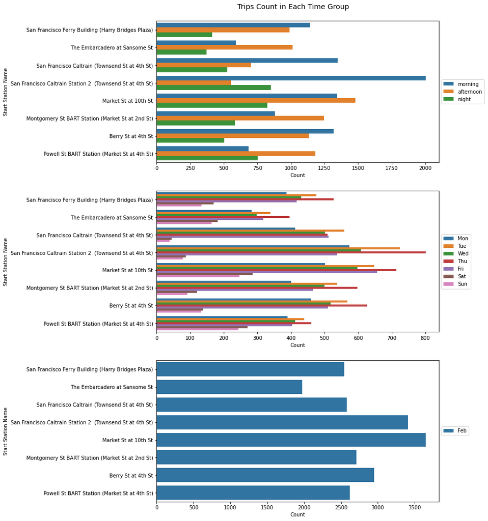

```python
# 2. Categorical variables by plotting countplot: top 8 stations by times (time of day, weekdays, months)
fig = plt.figure(figsize=(10,16))
plt.subplots_adjust(top=0.95)
fig.suptitle('Trips Count in Each Time Group', fontsize=14)
for i in range(1, 4):
    ax = fig.add_subplot(3, 1, i)
    sb.countplot(data=df, y='start_station_name', hue=times[i-1])
    plt.legend(loc='center left', bbox_to_anchor=(1,0.5))
    plt.ylabel('Start Station Name')
    plt.xlabel('Count');
```

After breaking down into each station,

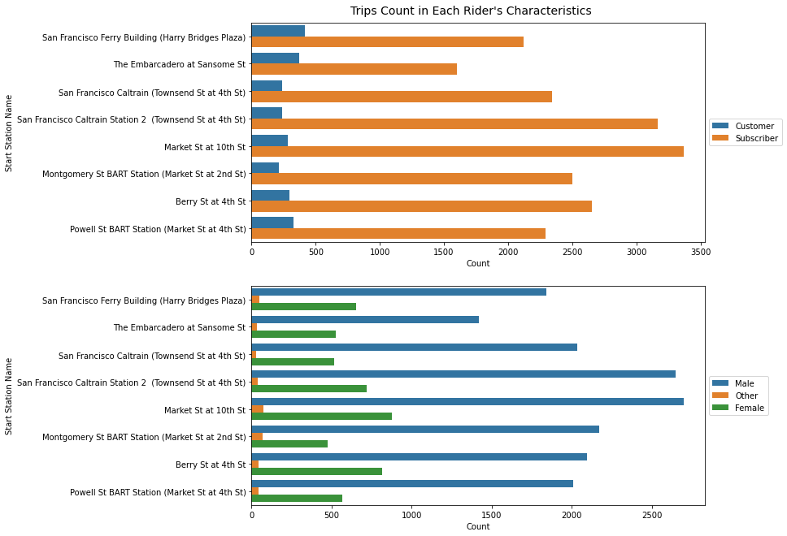

```python
# 3. Categorical variables by plotting countplot: top 8 stations by users' attributes (user_type, member's gender)
fig = plt.figure(figsize=(10,10))
plt.subplots_adjust(top=0.95)
fig.suptitle('Trips Count in Each Rider\'s Characteristics' , fontsize=14)
for i in range(1, 3):
    ax = fig.add_subplot(2, 1, i)
    sb.countplot(data=df, y='start_station_name', hue=users[i-1])
    plt.legend(loc='center left', bbox_to_anchor=(1,0.5))
    plt.ylabel('Start Station Name')
    plt.xlabel('Count');
```

After breaking down into top 8 station by users' attributes:

1. Apparently, subscribers are more than customers in each station. However, there are more customers at San Francisco Ferry Building (Harry Bridges Plaza) than at other stations. Customers might include tourists.
2. The trips in male riders are way more than in females. It cannot explain why males riders are more. It needs to be investigated deeper.

### Talk about some of the relationships you observed in this part of the investigation. How did the feature(s) of interest vary with other features in the dataset?

> Gender: the number of trips in males is way more than the number in females. It needs to be investigated more.

> There are more trips during the weekdays than in weekends. However, in customers, some stations like San Francisco Ferry Building (Harry Bridges Plaza) and The Embarcadero at Sansome St stations have more trips than others in the weekend.

### Did you observe any interesting relationships between the other features (not the main feature(s) of interest)?

> Subscribe: the number of trips in subscribers is more than the number in customers because of pricing and population.

## Multivariate Exploration

```python
# (1) Top 8 trip stations by times: separate user types and take a look customers and subscribers individually
df_cust = df.query('user_type == "Customer"')
df_sub = df.query('user_type == "Subscriber"')
```

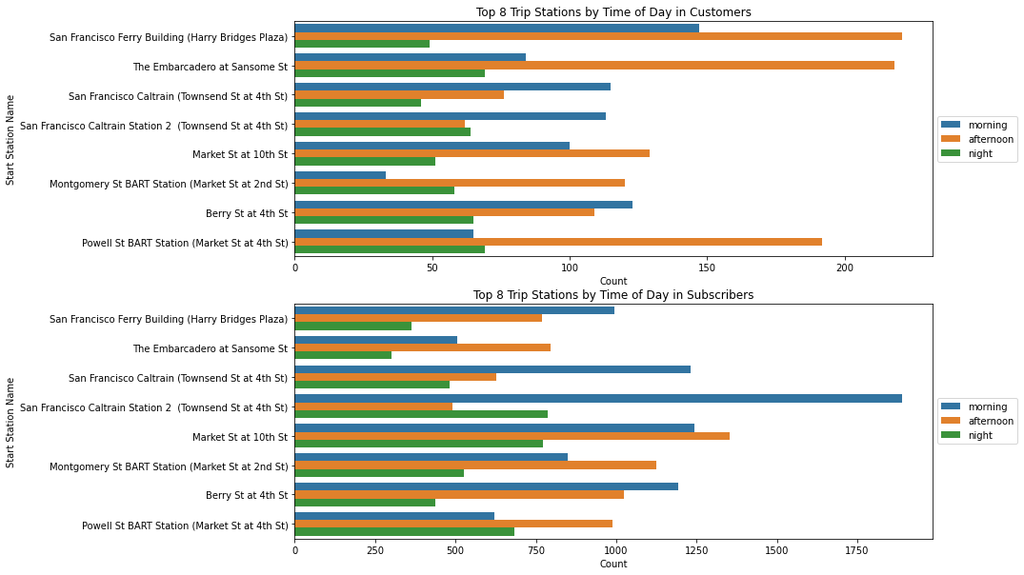

```python
# 1. 3 categorical variables using countplot: time of day: morning, afternoon, night between customers and subscribers
plt.figure(figsize=(12,10))
ax = plt.subplot(211)
sb.countplot(data=df_cust, y='start_station_name', hue='period_day')
plt.legend(loc='center left', bbox_to_anchor=(1,0.5))
plt.title('Top 8 Trip Stations by Time of Day in Customers')
plt.xlabel('Count')
plt.ylabel('Start Station Name')

ax = plt.subplot(212)
sb.countplot(data=df_sub, y='start_station_name', hue='period_day')
plt.legend(loc='center left', bbox_to_anchor=(1,0.5))
plt.title('Top 8 Trip Stations by Time of Day in Subscribers')
plt.xlabel('Count')
plt.ylabel('Start Station Name');
```

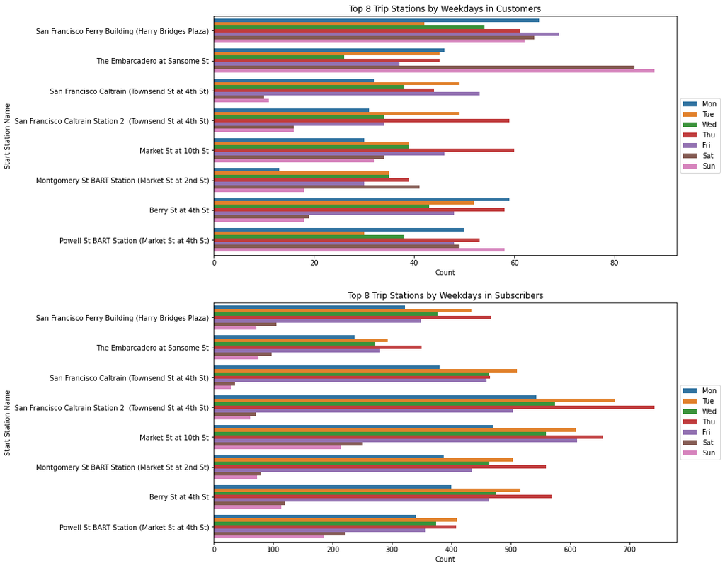

```python
# 2. 3 categorical variables using countplot: Weekday between customers and subscribers
plt.figure(figsize=(12,14))
ax = plt.subplot(211)
sb.countplot(data=df_cust, y='start_station_name', hue='start_weekday_char')
plt.legend(loc='center left', bbox_to_anchor=(1,0.5))
plt.title('Top 8 Trip Stations by Weekdays in Customers')
plt.ylabel('Start Station Name')
plt.xlabel('Count')

ax = plt.subplot(212)
sb.countplot(data=df_sub, y='start_station_name', hue='start_weekday_char')
plt.legend(loc='center left', bbox_to_anchor=(1,0.5))
plt.title('Top 8 Trip Stations by Weekdays in Subscribers')
plt.ylabel('Start Station Name')
plt.xlabel('Count');
```

```python
# Let's take a look at gender groups in time and locations
df_f = df.query('member_gender == "Female"')
df_m = df.query('member_gender == "Male"')
```

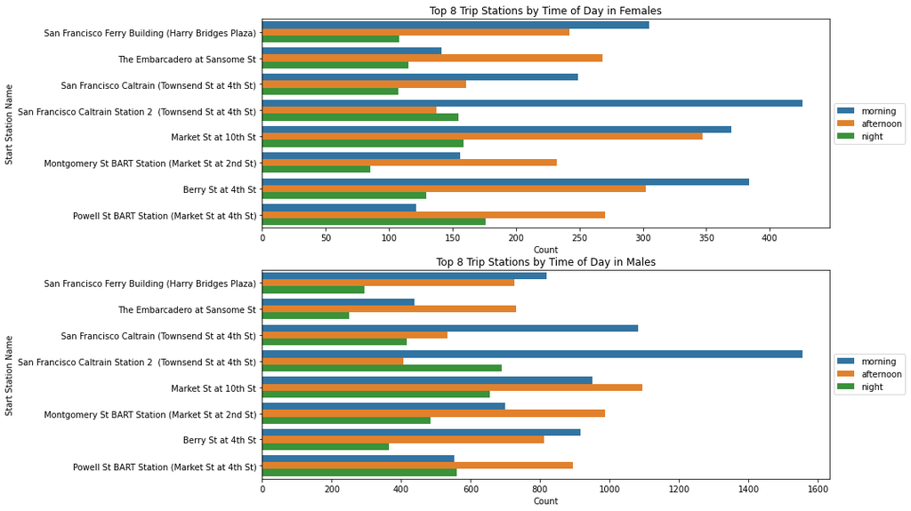

```python
# (2) Top 8 trip stations by times in each gender
# 1. 3 categorical variables using countplot: Time of day
plt.figure(figsize=(12,10))
ax = plt.subplot(211)
sb.countplot(data=df_f, y='start_station_name', hue='period_day')
plt.legend(loc='center left', bbox_to_anchor=(1,0.5))
plt.title('Top 8 Trip Stations by Time of Day in Females')
plt.xlabel('Count')
plt.ylabel('Start Station Name')

ax = plt.subplot(212)
sb.countplot(data=df_m, y='start_station_name', hue='period_day')
plt.legend(loc='center left', bbox_to_anchor=(1,0.5))
plt.title('Top 8 Trip Stations by Time of Day in Males')
plt.xlabel('Count')
plt.ylabel('Start Station Name');
```

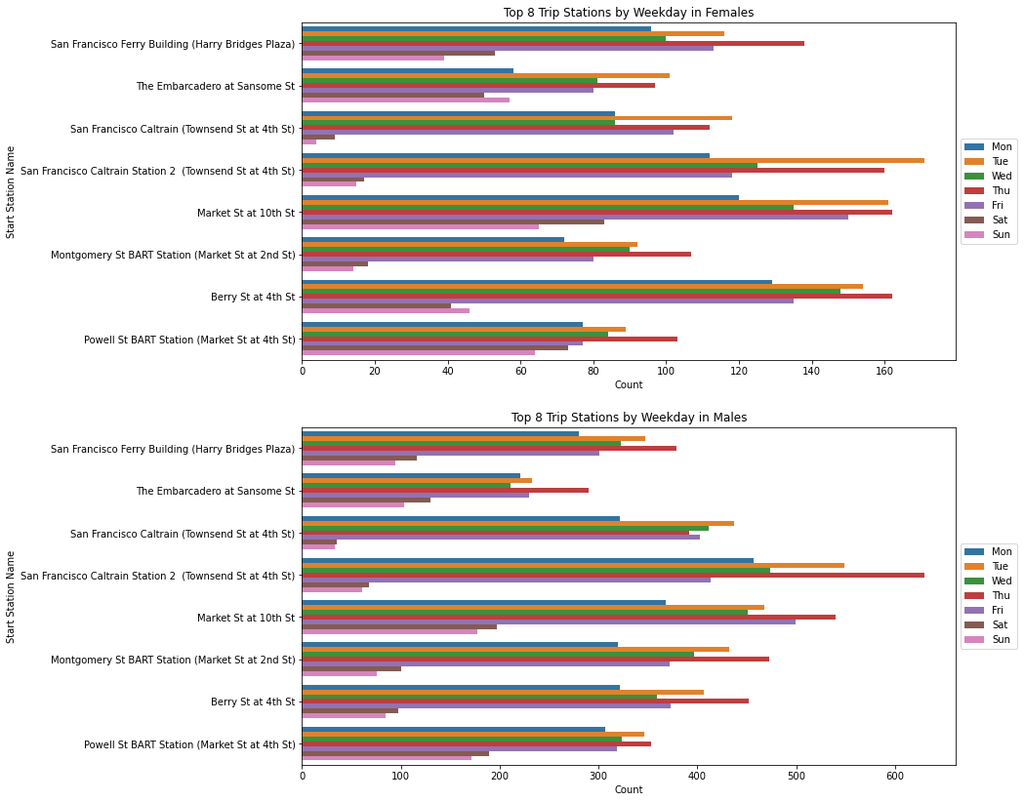

```python
# 2. 3 categorical variables using countplot: Weekday
plt.figure(figsize=(12,14))
ax = plt.subplot(211)
sb.countplot(data=df_f, y='start_station_name', hue='start_weekday_char')
plt.legend(loc='center left', bbox_to_anchor=(1,0.5))
plt.title('Top 8 Trip Stations by Weekday in Females')
plt.xlabel('Count')
plt.ylabel('Start Station Name')

ax = plt.subplot(212)
sb.countplot(data=df_m, y='start_station_name', hue='start_weekday_char')
plt.legend(loc='center left', bbox_to_anchor=(1,0.5))
plt.title('Top 8 Trip Stations by Weekday in Males')
plt.xlabel('Count')
plt.ylabel('Start Station Name');
```

## Conclusions

> Most trips were taken on Thursdays and Tuesdays

> Weekends have the least trip records

> The rush hours; going to work in the morning (8 and 9 hrs) and closing in the evening (17 and 18 hrs) have the highest trip records

> About 90% of the trips were taken by subscribers

> For both types of users the distribution of rides during the weekdays depends a lot on the hour of the day and day of the week.